# An Introduction to R

9th January 2017

## Overview

- Why now?
- Why R?
- General tips
- Recommended packages
- Recommended resources

## Why now?

### Efficiency

- Point-and-click software just isn't time efficient
- Automating tasks will pay off within the time frame of a PhD and thereafter

## Why now?

### Reproducibility

- There is an increasing expectation that materials, data, and analysis details are provided alongside research to ensure it is reproducible
  - This is easier when things are script based
- [Peer Reviewers' Openness Initiative](https://opennessinitiative.org/)

## Why R?

### Jobs

- R is increasingly taught in Psychology departments, including at undergraduate level
- Useful skill for jobs outside academia
- Makes you a more efficient academic

## Why R?

### Pretty graphs

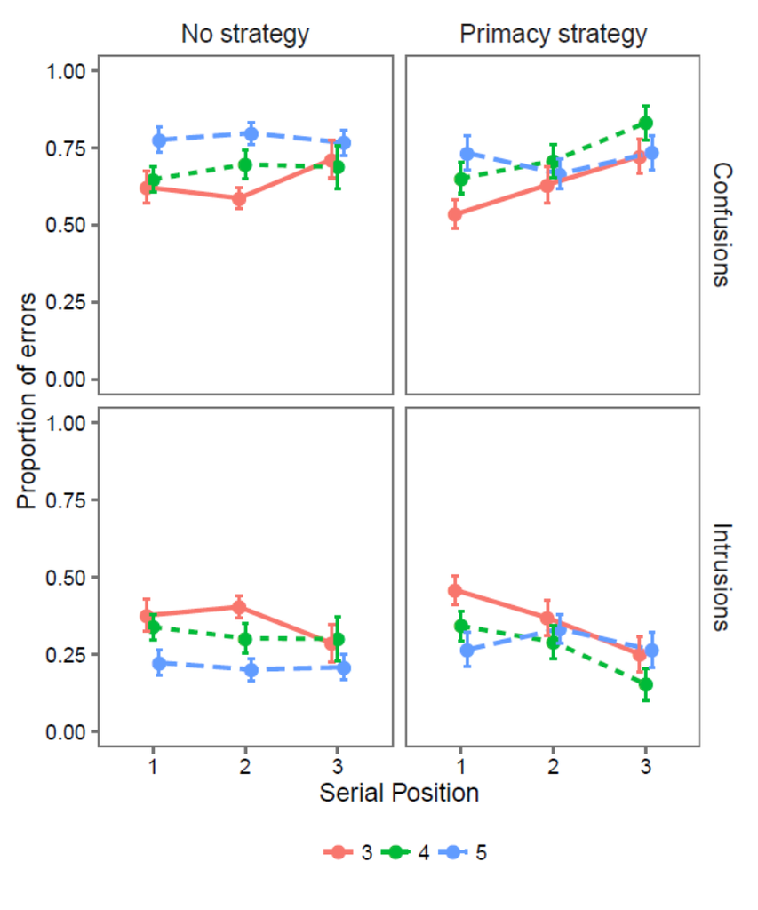

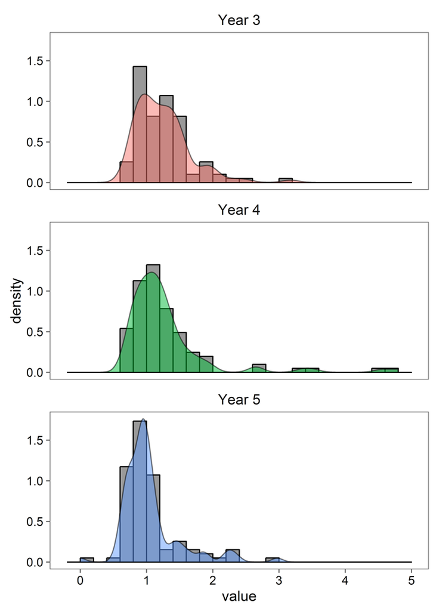

## Why R?

### Range of packages

- There are R packages for a huge range of analyses
- Great data manipulation packages
- Slides
- Documents
  - Including books
- Interactive HTML applications

## Why R?

### Reproducibility… again

- R projects
- R Markdown

## Why R

- It's free
- Big community
- R has the [happiest commenters](https://hackernoon.com/which-programming-languages-have-the-happiest-and-angriest-commenters-ebe91b3852ed#.fpgwgsb03)

## Recommended packages

## General comments

- Given the age of R there are many ways to complete a task
- Most data manipulation tasks can be done with 'base R'
  - However, this often isn't the most efficient or readable approach

## tidyverse

- A collection of packages by Hadley Wickham for:
  - Data visualisation (ggplot2)
  - Data manipulation (dplyr)
  - Data tidying (tidyr)
  - Importing data (readr)
  - Functional programming (purrr)
    - See [here](https://blog.rstudio.org/2016/09/15/tidyverse-1-0-0/) for a full list of the included packages
- These packages are all designed to work nicely together
- More readable by people than most R code

## Installing tidyverse

- To install and load any package you just do:

```r
install.packages("tidyverse")
library(tidyverse)
```

- You need to load a package in with `library()` for any new R session you want to use it with
- Loading tidyverse loads all the packages described previously

## Recommended packages

### The pipe operator

- The pipe operator is key to why the tidyverse packages are so usable and readable
- It passed the thing on its left as the first argument to a function on its right
  - x %>% f() is equivalent to f(x)

```r
x <- c(10, 5, 15)

mean_x <- x %>% mean()
```

- This is amazing for chaining together the various steps some data goes through without needing to create intermediary objects
- Doesn't work so smoothly with some packages

## ggplot2

- Build graphs by specifying:
  - Aesthetics: physical properties of the plot mapped to variables in the data (x & y positions, size, shape, colour etc.)
  - Geometries: what to actually use to represent the data (lines, bars, points etc.)

## ggplot2

### qplot

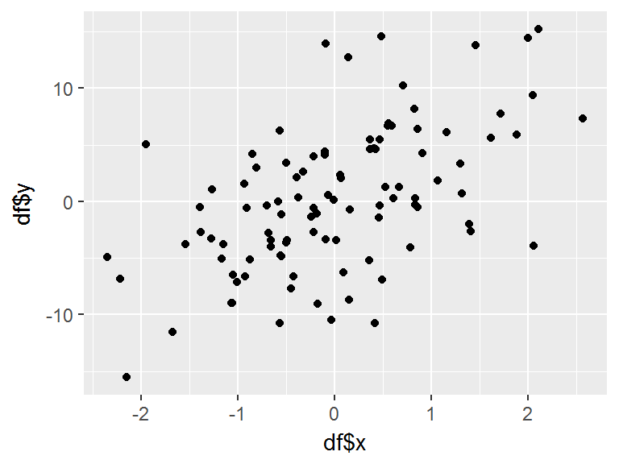

```r
qplot(x = df$x, y = df$y)
```

## ggplot2

### qplot

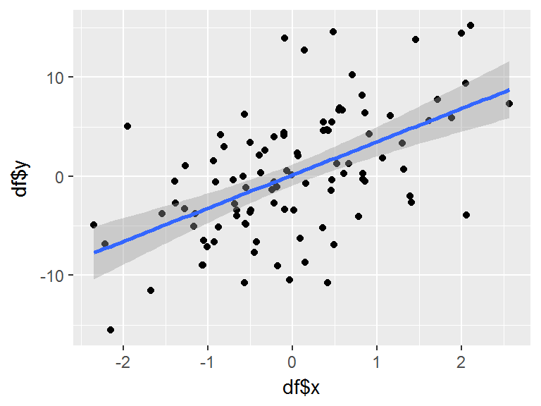

```r
qplot(df$x, df$y) +
  geom_smooth(method = "lm")
```

## ggplot2

### ggplot

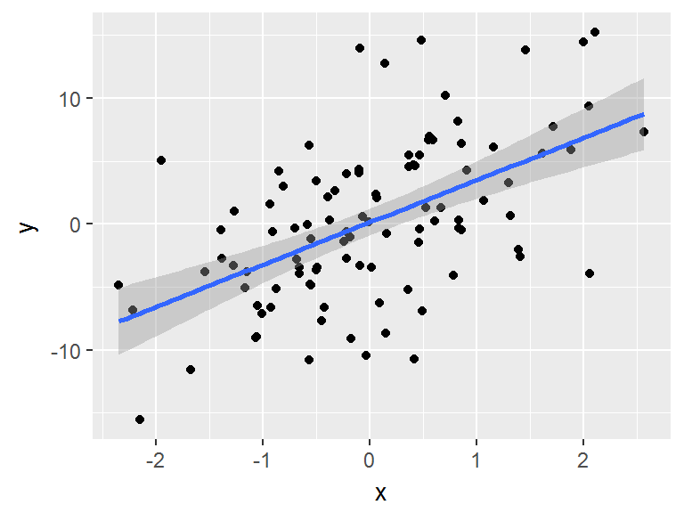

```r
ggplot(data = df, mapping = aes(x = x, y = y)) +
  geom_point() +
  geom_smooth(method = "lm")
```

## ggplot2

### ggplot

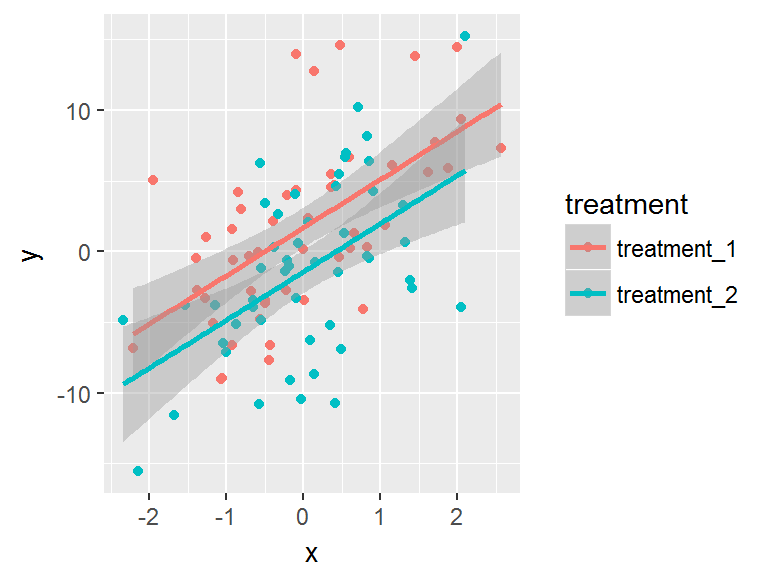

```r
ggplot(data = df, mapping = aes(x = x, y = y, colour = treatment)) +
  geom_point() +
  geom_smooth(method = "lm")
```

## ggplot2

### Other tips

- The package `ggthemes` is good for providing premade plot 'styles'
- `RColorBrewer` is useful for colours
- `cowplot` is good for creating grids of labelled plots for papers
  - `cowplot` [vignette](https://cran.r-project.org/web/packages/cowplot/vignettes/introduction.html)

## ggplot2

### Other tips

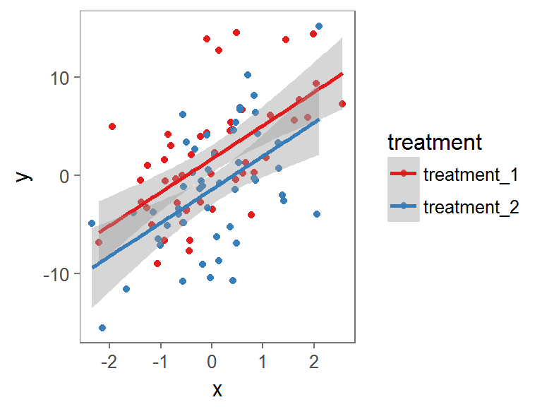

```r
ggplot(df, aes(x, y, colour = treatment)) +
  geom_point() +
  geom_smooth(method = "lm") +
  theme_few() +
  scale_color_brewer(palette = "Set1")
```

## cowplot

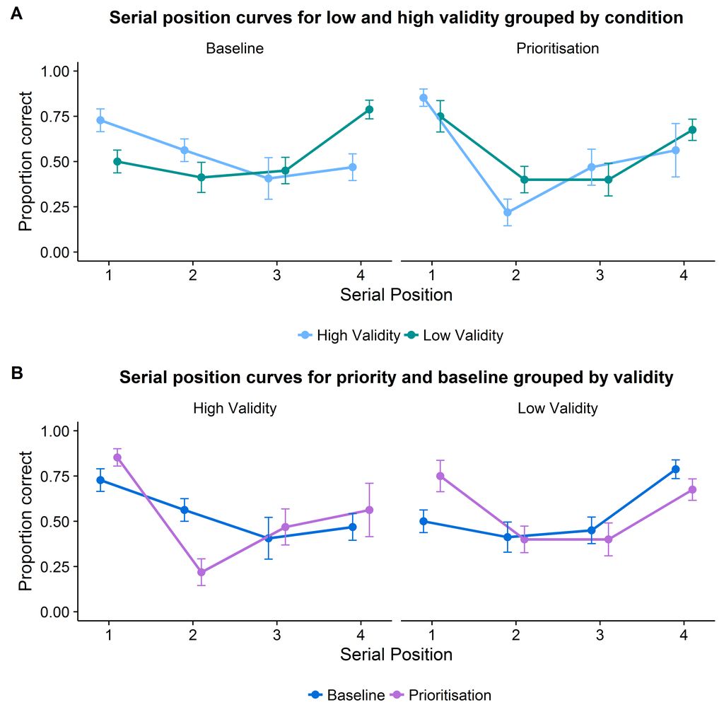

## Data visualisation

### Other options

- Three main options for data visualation: `base`, `lattice`, and `ggplot2`
- `base` automatically produces certain plots when called on certain objects
  - e.g. calling `plot()` on a regression model object will produce diagnostic plots
- In my view `ggplot2` is the easiest to learn - but that's probably because it the only one I'm good at!
  - See these posts for arguments [for](http://varianceexplained.org/r/why-I-use-ggplot2/) and [against](http://simplystatistics.org/2016/02/11/why-i-dont-use-ggplot2/) `ggplot2` over `base` for plots

## dplyr

### overview

- `dplyr` is designed around a set of basic 'verbs':
  - `filter()`: filter rows
  - `arrange()`: arrange rows (e.g. ascending)
  - `select()`: select columns
  - `distinct()`: get unique rows
  - `mutate()`: create new variables
  - `summarise()`: summarise the data
- Also has functions for joining data and lots of 'helper' functions

## dplyr

### Some example data

```
## # A tibble: 10 × 5
##       id    stage      cond1      cond2  group
##    <int>    <chr>      <dbl>      <dbl>  <chr>
## 1      1 practice  0.1636760  0.7083730 group1
## 2      1     test -1.2907701 -1.0528022 group1
## 3      2 practice -0.6169888  0.2493767 group1
## 4      2     test -1.1242995 -0.9428229 group1
## 5      3 practice  0.9936428 -1.0411515 group1
## 6      3     test -0.6204167 -0.9610288 group1
## 7      4 practice  0.6451879  0.8630745 group1
## 8      4     test -2.1636987  0.9780847 group1
## 9      5 practice  0.9715775  0.4290645 group1
## 10     5     test  1.1030193 -1.1431119 group1
```

## dplyr

### Summarising the data

```r
sum_stats <- df1 %>%
  filter(stage == "test") %>%
  mutate(cond_diff = cond1 - cond2) %>%
  group_by(group) %>%
  summarise(mean = mean(cond_diff),
            sd = sd(cond_diff),
            n = n(),
            se  = sd/sqrt(n))
```

```
## # A tibble: 2 × 5
##    group       mean       sd     n        se
##    <chr>      <dbl>    <dbl> <int>     <dbl>
## 1 group1 -0.7841174 1.573702    15 0.4063280
## 2 group2  0.1441234 1.267532    15 0.3272753
```

## purrr

### overview

- `purrr` is a package for 'functional programming'
- The functions you're likely to use most are the `map()` functions
  - Apply a function to a list, vector or dataframe
  - Have versions where you specific the class of object you're expecting back
    - 'Safer' than the `apply` family
      - Either work or break with an informative error message
- Lots of other functions that are useful for writing your own functions
- Cool purrr tutorial [here](https://jennybc.github.io/purrr-tutorial/)

## purrr

### example

```r
list <- paste("data/", list.files("data"), sep = "")

df <- map_df(list, read_csv)
```

## tidyr

### Overview

- Functions for tidying data
- The thing to use for moving between long and wide data
- E.g. suppose we have the wide data from before

```
## # A tibble: 6 × 5
##      id stage      cond1      cond2  group
##   <int> <chr>      <dbl>      <dbl>  <chr>
## 1     1  test -1.2907701 -1.0528022 group1
## 2     2  test -1.1242995 -0.9428229 group1
## 3     3  test -0.6204167 -0.9610288 group1
## 4     4  test -2.1636987  0.9780847 group1
## 5     5  test  1.1030193 -1.1431119 group1
## 6     6  test  1.5917689  0.6568238 group1
```

## tidyr

### Example

```r
df1_long <- df1 %>%
  gather(condition, score, cond1:cond2) %>%
  arrange(id)
```

```
## # A tibble: 6 × 5
##      id    stage  group condition      score
##   <int>    <chr>  <chr>     <chr>      <dbl>
## 1     1 practice group1     cond1  0.1636760
## 2     1     test group1     cond1 -1.2907701
## 3     1 practice group1     cond2  0.7083730
## 4     1     test group1     cond2 -1.0528022
## 5     2 practice group1     cond1 -0.6169888
## 6     2     test group1     cond1 -1.1242995
```

## Recommended packages

### broom

- For cleaning up the outputs of modelling functions (vignette)
- Work very well with dplyr (vignette)

```
## # A tibble: 8 × 5
##      id  year     memory   attention attainment
##   <int> <chr>      <dbl>       <dbl>      <dbl>
## 1     1  five  0.6666020 -2.53801599  0.2830900
## 2     2  five -0.6228457 -0.70320317 -1.6741085
## 3     3  five -0.8709853  1.01129911  1.0417658
## 4     4  five  0.7033936  0.03484214  0.9088061
## 5     5  five -0.9226864  1.61259092 -0.1837895
## 6     6  five  0.3324768  1.10096835  0.8758124
## 7     7  five -0.9490558 -0.34564131 -0.6977495
## 8     8  five  0.8402922  0.81803298  1.6590892
```

## Recommended packages

### broom example (adapted from vignette)

```r
df2 %>%
  group_by(year) %>%
  do(tidy(lm(attainment ~ memory + attention, data = .)))
```

```
## Source: local data frame [6 x 6]
## Groups: year [2]
##
##    year        term   estimate std.error  statistic      p.value
##   <chr>       <chr>      <dbl>     <dbl>      <dbl>        <dbl>
## 1  five (Intercept)  0.2080013 0.1794559  1.1590667 2.565776e-01
## 2  five      memory  1.2106829 0.2065184  5.8623489 3.043036e-06
## 3  five   attention  0.7667066 0.1850296  4.1436980 3.023056e-04
## 4   two (Intercept) -0.1405709 0.1953475 -0.7195941 4.779579e-01
## 5   two      memory  1.1305056 0.1578598  7.1614552 1.059608e-07
## 6   two   attention  1.0008523 0.2372768  4.2180791 2.479966e-04
```

## Recommended packages

### rmarkdown

- `rmarkdown` provides a range of tools for creating dynamic documents in R [(see this intro)](http://rmarkdown.rstudio.com/lesson-1.html)
- Can be used to create:
  - Reports (e.g. a paper)
    - Outputs to MS Word, PDF, or HTML
  - Slides
  - [Interactive Notebooks](http://rmarkdown.rstudio.com/r_notebooks.html)
  - Books via `bookdown`
  - See [here](http://rmarkdown.rstudio.com/formats.html) for a full list of formats

## Recommended packages

### rmarkdown

- Code can be embedded to make reproducible reports

**74** participants took part in Experiment 1 (Mean age = **8.65**, SD = **1.32**).

`` `r nrow(wide)` `` participants took part in Experiment 1 (Mean age = `` `r round(mean(wide$age), 2)` ``, SD = `` `r round(sd(wide$age), 2)` ``).

+ See [here](https://github.com/eddjberry/cutoff) for a useful function I've written for rounding values in R Markdown

## General tips

### R Studio

- Lots of useful stuff for R Markdown
- Generally just nice
- Download here: https://www.rstudio.com/products/rstudio/download/

## General tips

### R Projects

- Great for organising bits of code related to a single project
  - Raw data, processing script, processed data, analysis scripts, and manuscript all in one place
- Git intergration
- With a bit of code at the top of the manuscript you have a fully reproducible workflow
- Introduction to projects [here](http://r4ds.had.co.nz/workflow-projects.html)

```r
source("scripts/data-processing.R")
source("scripts/analysis.R")
source("scripts/exploratory-analysis.R")
```

## General tips

### Organising projects

- Some useful advice [here](https://pagepiccinini.com/r-course/lesson-1-r-basics/) on setting up a project (plus Git)
  - The advice for organisation is to have folders for data, figures, scripts and write-up
- When working with a project the top folder is your working directory. This makes it very easy to call files from other folders

```r
read_csv("data/exp-data-07-16.csv")
```

## General tips

### Projects and R markdown

- Note that when you run an R Markdown file the working directory is changed to the location of that file.
- if we have our file in a subfolder we need to change the way we call a file in different subfolder

```r
source("../scripts/data-processing.R")
```

- `"../"` tells it to start at the parent folder of the current working directory

## General tips

### Reuse and improve

- Obviously the point of writing scripts is that they can be reused
- However, don't just settle for whatever worked first. Try to work out the best way to do something
  - 'If you aren't getting frustrated you aren't learning' - Hadley Wickham
- Trying to improve old code when you revisit is a useful exercise

## Recommended resources

## Recommended resources

### Datacamp

- This is how I did most of my learning
- They have loads of great courses, particularly:
  - [Introduction to R](https://www.datacamp.com/courses/free-introduction-to-r) & [Intermediate R](https://www.datacamp.com/courses/intermediate-r)
  - [Data Manipulation in R with dplyr](https://www.datacamp.com/courses/dplyr-data-manipulation-r-tutorial), [Joining Data in R with dplyr](https://www.datacamp.com/courses/joining-data-in-r-with-dplyr) & [Cleaning Data in R](https://www.datacamp.com/courses/cleaning-data-in-r)
  - [Data Visualisation with ggplot2](https://www.datacamp.com/courses/data-visualization-with-ggplot2-1)
  - [Writing Functions in R](https://www.datacamp.com/courses/writing-functions-in-r)
  - [Reporting with R Markdown](https://www.datacamp.com/courses/reporting-with-r-markdown)
- Some of the courses can be tried for free

## Recommended resources

### Online stuff

- [Coursera Data Science Specialisation](https://www.coursera.org/specializations/jhu-data-science/1?utm_medium=courseDescripTop)
  - I've not done it but hear that it's good.
- [R Cookbook](http://www.cookbook-r.com/)
  - Though some of the solutions are now a bit out of date
- [R Studio blogs](https://blog.rstudio.org/)
  - Lots of good blogs accompany package updates.

## Recommended resources

### Online stuff

- Stack Overflow
  - You'll end up there by Googling a question
- [R Studio cheatsheets](https://www.rstudio.com/resources/cheatsheets/)
- R Studio R Markdown [website](http://rmarkdown.rstudio.com/)
- There are loads of good blogs out there that you can find from Googling
  - Note the date of a blog post as the advice might be out of date

## Recommended resources

### Online stuff

- Package vignettes
  - E.g. [Intro to dplyr](https://cran.r-project.org/web/packages/dplyr/vignettes/introduction.html)

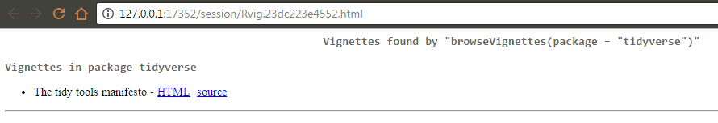

```r
browseVignettes(package = "tidyverse")
```

## Recommended resources

### Finding vignettes via Googling

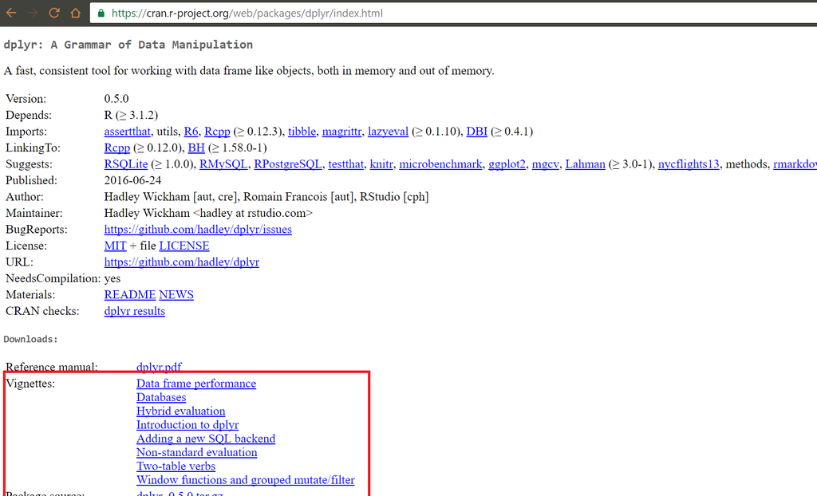

## Recommended resources

### Books

- [R for Data Science](http://r4ds.had.co.nz/) by Garrett Grolemund & Hadley Wickham
- [bookdown: Authoring Books and Technical Documents with R Markdown](https://bookdown.org/yihui/bookdown/) by Yihui Xie
- [Dynamic Documents with R and Knitr](https://www.amazon.co.uk/Dynamic-Documents-knitr-Second-Chapman/dp/1498716962/ref=asap_bc?ie=UTF8) by Yihui Xie
- [Discovering Statistics Using R](https://www.amazon.co.uk/Discovering-Statistics-Using-Andy-Field/dp/1446200469/ref=sr_1_4?s=books&ie=UTF8&qid=1483428752&sr=1-4&keywords=andy+field) by Andy Field
  - Published in 2012 so the stuff on data manipulation, in particular, is out of date